# Chapter 2 - The beta distribution

We can think of the beta distribution as a **probability distribution of probabilities**.

## 2.1 Batting averages

This book is going to showcase empirical Bayes methods with examples from baseball. While I’m not a baseball fan, the examples should still be illuminating to me (hopefully).

In baseball, a well known statistic is a player’s batting average, which is the number of hits over the number of at-bats:

$$\text{ Batting Average } =
\frac{H}{AB}$$

#### Some baseball information

- In general, a batting average of .270 is typical, while .300 is excellent.

#### On “prior expectations”

One thing that Robinson brings up is that if we want to a predict a player’s season-long batting average, using their batting average so far would be a bad way of predicting it. Why? Well, what if a player’s first few at-bats all result in hits? Or, what if they all result in misses? This doesn’t tell us much since we’ve only seen a few events.

More importantly, as Robinson points out, we’re going into this with **prior expectations** about a player’s batting average. Throughout baseball, batting averages over a season range from .210 to .360, (with some outliers on either end of the range). Even if a player does extremely well or poorly at their first few at-bats, their batting average at the end of the season is unlikely to deviate from the range of [.210, .360].

#### Modeling at-bats

Getting back to predicting a player’s batting average, we can model it with a **binomial distribution**, as it models a count of successes over a total number of trials. Our prior can be modeled with a **beta distribution**.

**NOTE:** The domain of the beta distribution is (0, 1) so this is incredibly useful for modeling probabilities!

## 2.2 Updating

Based on what we know, a player’s batting average is likely to be around .27, but it could range from .21 to .35. Therefore, we can say that a player’s batting average follows a beta distribution with parameters $\alpha$ and $\beta$. Robinson set $\alpha = 81$ and $\beta = 219$ so that the mean and variance are realistic for batting averages.

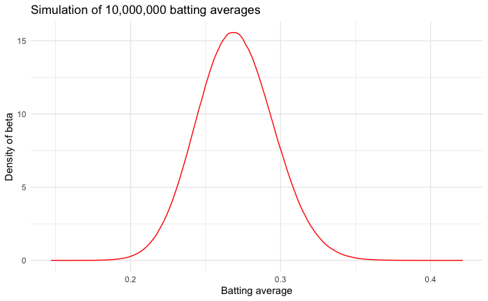

```r
sim_batting_averages <- tibble(
  batting_avg = rbeta(10000000, 81, 219)
) |>
  ggplot(aes(x = batting_avg)) +
  geom_density(color = "red") +
  labs(
    x = "Batting average",
    y = "Density of beta",
    title = "Simulation of 10,000,000 batting averages"
  )

sim_batting_averages
```

In the graph above, the x-axis represents the distribution of simulated batting averages, while the y-axis represents the probability density of the beta distribution (i.e. how likely is a given batting average?)

#### Utility of the beta distribution for “updating”

What’s neat about the beta distribution is that it gives us a way to easily model a binomial. When a player makes a hit, we want to move the curve over slightly to the right. In the case that they miss, we want to move it over slightly to the left.

This is the heart of Bayesian analysis. We have prior information about some quantity of interest, we observe new information, then create a **posterior distribution**, which takes into account our prior and new data.

The result of this “updating” for the beta is:

$$\text{Beta}(\alpha_0 + \text{hits},
\beta_0 + \text{misses})$$

where: * $\alpha_0$ = The prior for $\alpha$. * $\beta_0$ = The prior for $\beta$.

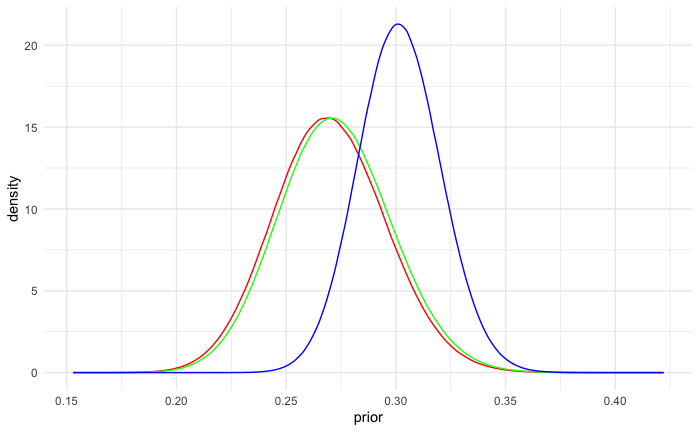

```r
sim_multiple_batting_averages <- tibble(
  prior = rbeta(10000000, 81, 219),
  one_at_bat = rbeta(10000000, 82, 219),
  three_hundred_at_bats = rbeta(10000000, 181, 419)
) |>
  ggplot(data = _) +
  geom_density(aes(x = prior), color = "red") +
  geom_density(aes(x = one_at_bat), color = "green") +
  geom_density(aes(x = three_hundred_at_bats), color = "blue")

sim_multiple_batting_averages
```

Above, we have three different distributions:

- In red, we have our prior.
- In green, we have our posterior distribution with a single hit.
- In blue, we have our posterior distribution with 100 hits at 300 at-bats.

With only one hit, our posterior distribution hardly shifts. However, with 100 hits at 300 at-bats, our posterior distribution **shifts** to the right and gets narrower, reflecting that we are more certain about the player’s batting average.

## 2.2.1 Posterior mean

The expected mean of a posterior beta distribution is:

$$\frac{\alpha}{\alpha + \beta}$$
In code:

```r
calculate_mean_beta <- function(alpha, beta) {
  alpha / (alpha + beta)
}

calculate_mean_beta(82 + 100, 219 + 200)
```

```
[1] 0.3028286
```

### 2.3 Conjugate prior

When we say a distribution is a **conjugate prior** of another distribution, we’re saying that it’s a convenient distribution to use for modeling (**I don’t like this sentence so figure out something better later**).

Below, we’re going to simulate 10,000,000 players from a $\text{Beta}(81, 219)$ distribution:

```r
num_trials <- 10e6

simulations <- tibble(
  true_average = rbeta(num_trials, 81, 219),
  hits = rbinom(num_trials, 300, true_average)
)

simulations
```

| true_average | hits |
| --- | --- |
| 0.2678101 | 85 |
| 0.2841969 | 84 |
| 0.2867300 | 89 |
| 0.2792470 | 80 |
| 0.2981290 | 88 |
| 0.2681925 | 86 |
| 0.2900915 | 92 |
| 0.2624010 | 88 |
| 0.2645533 | 87 |
| 0.2621662 | 69 |

[output cut: 990 more lines]

Next, we want to look at how many simulated players got 100/300 hits:

| true_average | hits |
| --- | --- |
| 0.3315878 | 100 |
| 0.2958743 | 100 |
| 0.3059786 | 100 |
| 0.2887285 | 100 |
| 0.3239665 | 100 |
| 0.3036798 | 100 |
| 0.2877689 | 100 |
| 0.3354518 | 100 |
| 0.3036481 | 100 |
| 0.2811562 | 100 |

[output cut: 990 more lines]

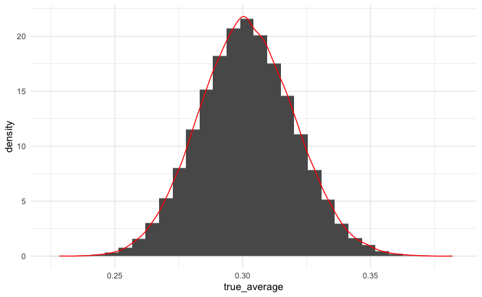

```r
hit_100 |>
  ggplot(data = _) +
  geom_histogram(aes(x = true_average, y = ..density..)) +
  geom_density(aes(x = true_average), color = "red")
```

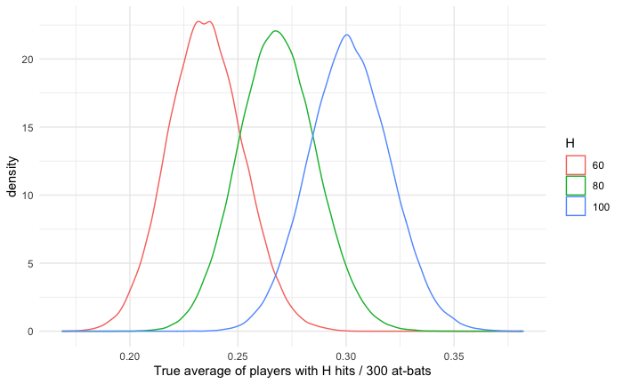

```r
simulations |>
  filter(hits %in% c(60, 80, 100)) |>
  ggplot(aes(x = true_average, color = factor(hits))) +
  geom_density() +
  labs(
    x = "True average of players with H hits / 300 at-bats",
    color = "H"
  )
```